### movie reviews sentiment analysis - Bag of Words Meets Bags of Popcorn

```
library(data.table)
library(tidytext)
library(text2vec)
library(caret)
library(SnowballC)
library(glmnet)
library(ROCR)
library(plyr)
library(ggplot2)
library(e1071)
library(kernlab)
library(randomForest)
```

情感分析(Sentiment Analysis)是文字探勘的重要應用之一，以下練習使用 [Kaggle](https://www.kaggle.com/c/word2vec-nlp-tutorial/data) 提供的資料集，其中 labeledTrainData.tsv 是包含標籤(0:負評,1:正評)的影評資料(25000筆)，unlabeledTrainData.tsv 則是沒有標籤的影評資料(50000筆)，將利用這些資料進行訓練、建模，目的是正確分類出影評所屬的極性 (polarity)。下圖為本次練習的大致流程

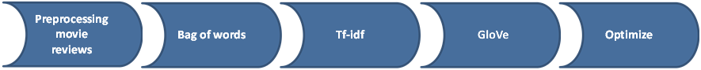

#### **Preprocessing and extracting movie reviews**

首先，利用 read.table 讀入 labeledTrainData.tsv，該檔案包含三個欄位：id、sentiment 和 review

```
## Classes 'data.table' and 'data.frame':   25000 obs. of  3 variables:
##  $ id       : chr  "0_3" "0_9" "10000_4" "10000_8" ...
##  $ sentiment: int  0 1 0 1 1 0 0 1 0 1 ...
##  $ review   : chr  "Story of a man who has unnatural feelings for a pig. Starts out with a opening scene that is a terrific example of absurd comed"| __truncated__ "Bromwell High is a cartoon comedy. It ran at the same time as some other programs about school life, such as \"Teachers\". My 3"| __…
##  - attr(*, "sorted")= chr "id"
##  - attr(*, ".internal.selfref")=<externalptr>
```

查看 sentiment 欄位資料比例，negative、positive 都是50%

```
##
##   0   1
## 0.5 0.5
```

除了進行以下的字串清理，也利用 tidytext 套件中 stop_words (lexicon==‘onix’) 設定停用字

```r
# 字串清理
cleanText <- function(chr) {
  # 刪除 links
  chr = gsub("(f|ht)(tp)(s?)(://)(.*)[.|/](.*)", " ", chr)
  # 刪除 html tag
  chr = gsub("<.*?>", " ", chr)
  # 刪除數字
  chr = gsub("[[:digit:]]", " ", chr)
  # 刪除控制字元
  chr = gsub("[[:cntrl:]]", " ", chr)
  # 刪除非字母
  chr = gsub("[^a-zA-Z' ]+", " ", chr)
  # 轉小寫
  chr = tolower(chr)
  # 刪除tab及前後空白
  chr = gsub("[ \t]{2,}", " ", chr)
  chr = gsub("^\\s+|\\s+$", "", chr)
  chr
}
```

由於是情感分析，參考了幾個 sentiment lexicon，了解一下情感字詞的 POS 特性，使用 tidytext 套件的 parts_of_speech 發現，lexicon 中大於 3% 的詞類皆為以下6種(事實上，parts_of_speech 中 words 的詞類也是這樣分佈)

```r
# Afinn lexicon
afinn.pos
```

```
## [1] "Noun"                  "Adjective"             "Verb (transitive)"
## [4] "Adverb"                "Verb (usu participle)" "Plural"
```

```r
# Bing Liu lexicon
bing.pos
```

```
## [1] "Noun"                  "Adjective"             "Verb (transitive)"
## [4] "Adverb"                "Plural"                "Verb (usu participle)"
```

```r
# NRC lexicon
nrc.pos
```

```
## [1] "Noun"                  "Adjective"             "Adverb"
## [4] "Verb (transitive)"     "Plural"                "Verb (usu participle)"
```

經過字串的清理、POS過濾、stem還原，以id==’10008_2’資料為例，review是原始資料、review3是preprocessing後的資料

```
##                                                                                                                                                                                                                                                                                                          …
## 1: The film is bad. There is no other way to say it. The story is weak and outdated, especially for this country. I don't think most people know what a "walker" is or will really care. I felt as if I was watching a movie from the 70's. The subject was just not believable for the year 2007, even b…
##                                                                                                                                                                                                                                                                                                          …
## 1: film bad there no wai sai stori weak outdat especi for countri don't think peopl know walker will realli care felt wa movi subject wa just not believ for year even be set in dc think rang true for who too applaus were low quick at end didn't for don't think schrader realli thought film out ahe…
```

#### **Bag of words model**

接著，將movie_reviews轉成data.table，訓練/測試資料比採7:3

```r
setDT(movie_reviews)
setkey(movie_reviews, id)

set.seed(777)
all_ids <- movie_reviews$id
train_ids <- sample(all_ids, 0.7 * length(all_ids))
test_ids <- setdiff(all_ids, train_ids)
train <- movie_reviews[J(train_ids)]
test <- movie_reviews[J(test_ids)]
```

首先使用 Bag of words 方法，這裡使用 text2vec 套件去除停用字、建立 Document-term matrix (dtm)

```r
it_train = itoken(space_tokenizer(train$review3), ids = train$id, progressbar = FALSE)
vocab = create_vocabulary(it_train, stopwords = myStopWords[[1]])
vectorizer = vocab_vectorizer(vocab)
dtm_train = create_dtm(it_train, vectorizer)
```

訓練資料的 dtm 維度

```
## [1] 17500 23908
```

利用 glmnet 套件進行邏輯迴歸擬合，預測所得的 Confusion Matrix 如下，Accuracy : 0.8532

```
## Confusion Matrix and Statistics
##
##           Reference
## Prediction    0    1
##          0 3034  427
##          1  674 3365
##
##                Accuracy : 0.8532
##                  95% CI : (0.845, 0.8611)
##     No Information Rate : 0.5056
##     P-Value [Acc > NIR] : < 2.2e-16
##
##                   Kappa : 0.7061
##  Mcnemar's Test P-Value : 1.227e-13
##
##             Sensitivity : 0.8874
##             Specificity : 0.8182
##          Pos Pred Value : 0.8331
##          Neg Pred Value : 0.8766
##              Prevalence : 0.5056
##          Detection Rate : 0.4487
##    Detection Prevalence : 0.5385
##       Balanced Accuracy : 0.8528
##
##        'Positive' Class : 1
##
```

繪製 ROC curve (藍色線)

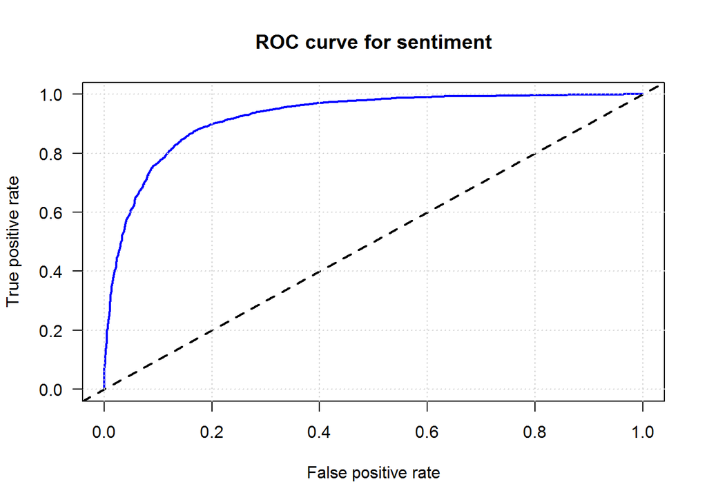

AUC 面積

```
## [1] 0.9236846
```

測試看看下面的句子，預測結果為 0: negative (預測正確!)

```r
myreview = "I was going to say something awesome or great or good, but I simply can't because the movie is
so bad."
```

```r
predict(glmnet.fit, dtm_myreview, type = 'class')[,1]
```

```
## [1] "0"
```

#### **Tf-idf model**

第二種試試 Tf-idf，將前面所得到的 dtm 進行 normalization 與 tfidf

```r
# normalization & TFIDF
normalizeTFIDF <- function(dtm) {
  model_tfidf = TfIdf$new(norm = "l1")
  dtm_norm_tfidf = fit_transform(dtm, model_tfidf)
  dtm_norm_tfidf
}

dtm_train_tfidf = normalizeTFIDF(dtm_train)
dtm_test_tfidf = normalizeTFIDF(dtm_test)
```

Tf-idf 預測得到的 Confusion Matrix 如下，Accuracy : 0.8507 (比前次的0.8532略低)

```
## Confusion Matrix and Statistics
##
##           Reference
## Prediction    0    1
##          0 3040  452
##          1  668 3340
##
##                Accuracy : 0.8507
##                  95% CI : (0.8424, 0.8587)
##     No Information Rate : 0.5056
##     P-Value [Acc > NIR] : < 2.2e-16
##
##                   Kappa : 0.7011
##  Mcnemar's Test P-Value : 1.324e-10
##
##             Sensitivity : 0.8808
##             Specificity : 0.8198
##          Pos Pred Value : 0.8333
##          Neg Pred Value : 0.8706
##              Prevalence : 0.5056
##          Detection Rate : 0.4453
##    Detection Prevalence : 0.5344
##       Balanced Accuracy : 0.8503
##
##        'Positive' Class : 1
##
```

繪製 ROC curve (紅色線)，感覺比藍色好一點點

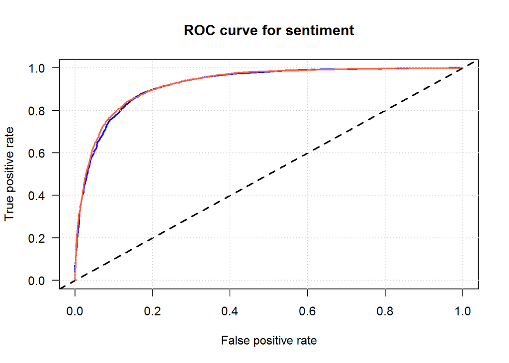

AUC 面積 (比前次的0.9236846略高)

```
## [1] 0.9265416
```

相同的測試句，這次預測結果為 1: positive (預測錯誤!)

```r
predict(glmnet.fit2, normalizeTFIDF(dtm_myreview), type = 'class')[,1]
```

```
## [1] "1"
```

#### **GloVe model**

第三種作法使用 GloVe，利用前面23908個詞彙產生term-co-occurence matrix (TCM)、建立 word vectors (size 設定為500)

```r
vectorizer_tcm <- vocab_vectorizer(vocab, grow_dtm = FALSE, skip_grams_window = 5)
# term-co-occurence matrix (TCM)
tcm_train <- create_tcm(it_train, vectorizer_tcm)
# GloVe algorithm
# maximum number of co-occurrences to use in the weighting function : x_max
glove = GlobalVectors$new(word_vectors_size = 500, vocabulary = vocab, x_max = 10)
# number of SGD iterations
glove$fit(tcm_train, n_iter = 10)
# get the word vectors
word_vectors <- glove$get_word_vectors()
```

換句話說，每個字詞可以用維度500的向量來表示

```r
dim(word_vectors)
```

```
## [1] 23908   500
```

接著將每則review的字詞對應到 word_vectors 加總平均，就是每一則review的向量。很明顯的，訓練資料的維度比之前的作法低很多很多

```
## [1] 17500   500
```

GloVe 預測得到的 Confusion Matrix 如下，Accuracy : 0.8364 (比前2次還低)

```
## Confusion Matrix and Statistics
##
##           Reference
## Prediction    0    1
##          0 3033  552
##          1  675 3240
##
##                Accuracy : 0.8364
##                  95% CI : (0.8278, 0.8447)
##     No Information Rate : 0.5056
##     P-Value [Acc > NIR] : < 2.2e-16
##
##                   Kappa : 0.6726
##  Mcnemar's Test P-Value : 0.0004961
##
##             Sensitivity : 0.8544
##             Specificity : 0.8180
##          Pos Pred Value : 0.8276
##          Neg Pred Value : 0.8460
##              Prevalence : 0.5056
##          Detection Rate : 0.4320
##    Detection Prevalence : 0.5220
##       Balanced Accuracy : 0.8362
##
##        'Positive' Class : 1
##
```

繪製 ROC curve (綠色線)，和紅、藍線相比，整體內縮

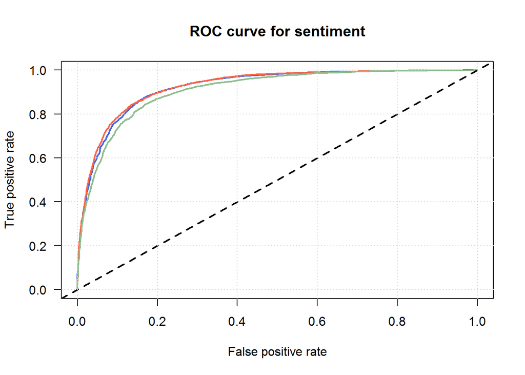

AUC 面積 (低於前2次的表現)

```
## [1] 0.9093764
```

相同的測試句，GloVe model的預測結果為 0: negative (預測正確!)

```r
predict(glmnet.fit3, as.matrix(documentWord2Vec(myreview)), type = 'class')[,1]
```

```
##   1
## "0"
```

#### **GloVe model including unlabeledTrainData**

雖然 GloVe 目前的表現在上述三種中是最差的，不過它使用的維度(500)在運算效能上有優勢，加上目前都只使用了 labeledTrainData.tsv 進行訓練(25000筆 * 0.7)，另外還有 unlabeledTrainData.tsv (50000筆)尚未利用。

這次合併2個檔案，相同的Preprocessing，產出新的 word_vectors 如下，可以發現參照的字詞由 23908 變成 33824

```r
dim(word_vectors_all)
```

```
## [1] 33824   500
```

一樣的word vectors size (500)，訓練資料筆數與維度如下

```
## [1] 17500   500
```

這次 GloVe 預測得到的 Confusion Matrix 如下，Accuracy : 0.8513 (明顯比前次 0.8364 高)

```
## Confusion Matrix and Statistics
##
##           Reference
## Prediction    0    1
##          0 3087  494
##          1  621 3298
##
##                Accuracy : 0.8513
##                  95% CI : (0.8431, 0.8593)
##     No Information Rate : 0.5056
##     P-Value [Acc > NIR] : < 2.2e-16
##
##                   Kappa : 0.7025
##  Mcnemar's Test P-Value : 0.000161
##
##             Sensitivity : 0.8697
##             Specificity : 0.8325
##          Pos Pred Value : 0.8415
##          Neg Pred Value : 0.8620
##              Prevalence : 0.5056
##          Detection Rate : 0.4397
##    Detection Prevalence : 0.5225
##       Balanced Accuracy : 0.8511
##
##        'Positive' Class : 1
##
```

繪製 ROC curve (黃色線)，已經逼近了紅、藍線

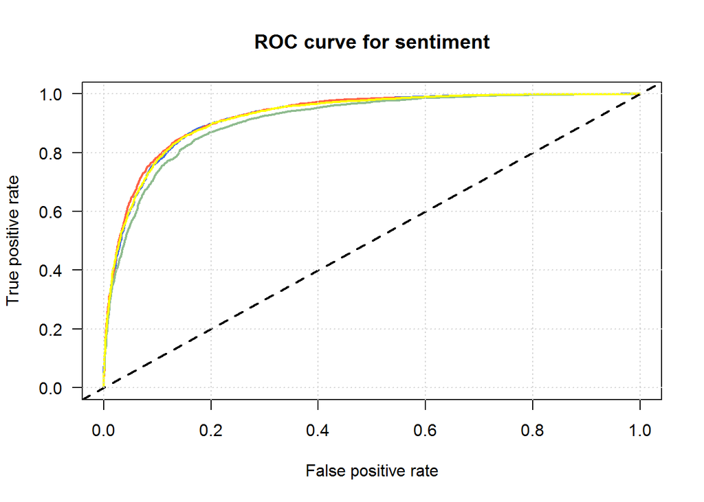

AUC 面積 (高於前次的0.9093764)

```
## [1] 0.9237812
```

相同的測試句，GloVe model的預測結果為 0: negative (預測正確!)

```r
predict(glmnet.fit4, as.matrix(documentWord2Vec_all(myreview)), type = 'class')[,1]
```

```
##   1
## "0"
```

#### **Optimized model**

上述都使用邏輯迴歸的方法，從ROC curve 黃色線可以看出 GloVe model 表現已經很不錯了。因此，接下來利用不同的演算法於 GloVe model 上試試，以下是其他演算法的表現

使用 e1071 套件 naiveBayes (laplace = 1)

```
##  Accuracy
## 0.7226667
```

使用 kernlab 套件 ksvm (kernel = “rbfdot”)

```
##  Accuracy
## 0.8617333
```

使用 randomForest 套件 randomForest (ntree = 500, mtry = sqrt(500))

```
##  Accuracy
## 0.8225333
```

從以上發現 SVM + GloVe model 的 Accuracy 是目前最高的，接下來利用 Cost 參數來優化 model。下圖是不同 Cost 參數執行的結果，可看出 C=3 時可以得到最佳的 Accuracy (0.8636)

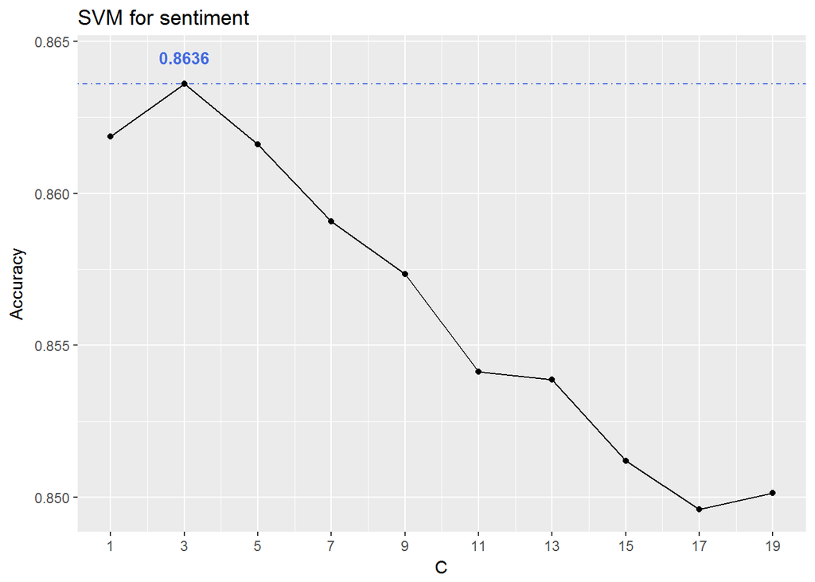

ksvm (kernel = “rbfdot”, C = 3) 預測得到的 Confusion Matrix 如下，Accuracy : 0.8636 (最高)

```
## Confusion Matrix and Statistics
##
##           Reference
## Prediction    0    1
##          0 3144  459
##          1  564 3333
##
##                Accuracy : 0.8636
##                  95% CI : (0.8556, 0.8713)
##     No Information Rate : 0.5056
##     P-Value [Acc > NIR] : < 2.2e-16
##
##                   Kappa : 0.7271
##  Mcnemar's Test P-Value : 0.001148
##
##             Sensitivity : 0.8790
##             Specificity : 0.8479
##          Pos Pred Value : 0.8553
##          Neg Pred Value : 0.8726
##              Prevalence : 0.5056
##          Detection Rate : 0.4444
##    Detection Prevalence : 0.5196
##       Balanced Accuracy : 0.8634
##
##        'Positive' Class : 1
##
```

繪製 ROC curve (黑色線)，超越其他色線

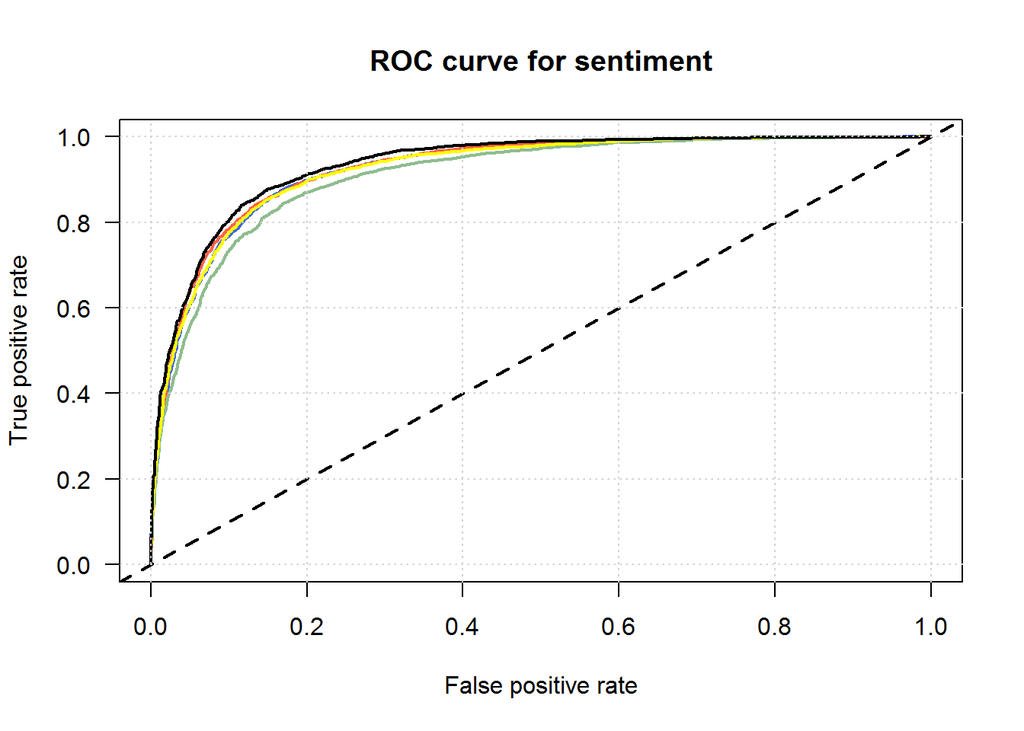

AUC 面積 (最大)

```
## [1] 0.934975
```

#### **Summary**

試著將以上執行結果彙整(如下表)，可以發現傳統向量空間模型(Bag of words、Tf-idf)的表現有一定水準，不過必須透過 labeled 資料進行訓練、建模，另外，高維度也是不可避免的，高稀疏值雖可設定刪除，但也會影響準確率。GloVe 方法則可利用 labeled 和 unlabeled 資料生成參照的 word vectors，參照資料越多、準確率也可望提升(參考 ROC curve 綠、黃、黑)，另外，維度的設定也可兼顧運算成本與效能。這次練習設定的維度為500，嘗試3種不同的演算法，發現 GloVe + SVM 的表現不俗(比一開始的logistic regression還好)，最後試著調整 Cost 參數，得到 C=3 時準確率最佳

| model | method | trainData | parameter | accuracy | AUC |
| --- | --- | --- | --- | --- | --- |
| Bag of words | logisticRegression | labeled |  | 0.8532000 | 0.923684649224622 |
| Tf-idf | logisticRegression | labeled |  | 0.8506667 | 0.926541612046489 |
| GloVe | logisticRegression | labeled |  | 0.8364000 | 0.909376365504626 |
| GloVe | logisticRegression | labeled+unlabeled |  | 0.8513333 | 0.923781230228622 |
| GloVe | naiveBayes | labeled+unlabeled |  | 0.7226667 |  |
| GloVe | randomForest | labeled+unlabeled |  | 0.8225333 |  |
| GloVe | SVM | labeled+unlabeled |  | 0.8617333 |  |
| GloVe | SVM | labeled+unlabeled | C=3 | 0.8636000 | 0.934974954369371 |

### Lessons Learned:

#### Sentiment analysis (polarity)